# Power spectral density

## Packages and commands

We’ll be using: * tidyverse

New comands will be: * separate() * spectrum()

First, load the **tidyverse**.

```r
library(tidyverse)
```

We’ll be using different example data for this exercise. Load **mne_data.csv** from the **data** folder using *read_CSV()*. Examine the data frame using *head()*.

```r
mne_data <- read_csv('../data/mne_data.csv', progress = FALSE)
head(mne_data)
```

```
## # A tibble: 6 x 67
##              condition epoch  time       Fp1       AF7        AF3
##                  <chr> <int> <int>     <dbl>     <dbl>      <dbl>
## 1 no light/no touch/no     0  -203  6.591397  1.860360  3.2197991
## 2 no light/no touch/no     0  -195  6.229770 -6.804366  0.5225619
## 3 no light/no touch/no     0  -188 10.432588 -2.410507 -3.2696203
## 4 no light/no touch/no     0  -180 13.737348  9.389730 -0.3534377
## 5 no light/no touch/no     0  -172 11.362003  7.662414  2.4597767
## 6 no light/no touch/no     0  -164  9.726110  7.337580  2.8859454
## # ... with 61 more variables: F1 <dbl>, F3 <dbl>, F5 <dbl>, F7 <dbl>,
## #   FT7 <dbl>, FC5 <dbl>, FC3 <dbl>, FC1 <dbl>, C1 <dbl>, C3 <dbl>,
## #   C5 <dbl>, T7 <dbl>, TP7 <dbl>, CP5 <dbl>, CP3 <dbl>, CP1 <dbl>,
## #   P1 <dbl>, P3 <dbl>, P5 <dbl>, P7 <dbl>, P9 <dbl>, PO7 <dbl>,
## #   PO3 <dbl>, O1 <dbl>, Iz <dbl>, Oz <dbl>, POz <dbl>, Pz <dbl>,
## #   CPz <dbl>, Fpz <dbl>, Fp2 <dbl>, AF8 <dbl>, AF4 <dbl>, AFz <dbl>,
## #   Fz <dbl>, F2 <dbl>, F4 <dbl>, F6 <dbl>, F8 <dbl>, FT8 <dbl>,
## #   FC6 <dbl>, FC4 <dbl>, FC2 <dbl>, FCz <dbl>, Cz <dbl>, C2 <dbl>,
## #   C4 <dbl>, C6 <dbl>, T8 <dbl>, TP8 <dbl>, CP6 <dbl>, CP4 <dbl>,
## #   CP2 <dbl>, P2 <dbl>, P4 <dbl>, P6 <dbl>, P8 <dbl>, P10 <dbl>,
## #   PO8 <dbl>, PO4 <dbl>, O2 <dbl>
```

This data is in wide format. We need to it be in long format. Use *gather()* to convert it. Remember that we want to keep the condition, epoch, and time variables as they are. Also of note is the condition variable. We need to split it into several different columns. Use *separate()* from **dplyr**.

```r
mne_data <- mne_data %>%
  gather(electrode, amplitude, -condition, -epoch, -time) %>%
  separate(condition, c("light","touch","report"), sep = "/")
```

## Frequency analysis

R has several possible commands to perform FFTs. Here we’ll use the base R method *spectrum()*.

We want to calculate the power spectrum for every trial, for every electrode, then average over them. We’ll *nest()* time and amplitude within the data frame first.

```r
spec_psd <- mne_data %>%
  nest(time, amplitude)

spec_psd
```

```
## # A tibble: 25,280 x 6
##       light    touch report epoch electrode              data
##       <chr>    <chr>  <chr> <int>     <chr>            <list>
##  1 no light no touch     no     0       Fp1 <tibble [91 x 2]>
##  2 no light    touch     no     1       Fp1 <tibble [91 x 2]>
##  3    light    touch     no     2       Fp1 <tibble [91 x 2]>
##  4 no light    touch    yes     3       Fp1 <tibble [91 x 2]>
##  5    light no touch     no     4       Fp1 <tibble [91 x 2]>
##  6    light no touch    yes     5       Fp1 <tibble [91 x 2]>
##  7 no light    touch    yes     6       Fp1 <tibble [91 x 2]>
##  8    light    touch     no     7       Fp1 <tibble [91 x 2]>
##  9 no light no touch     no     8       Fp1 <tibble [91 x 2]>
## 10 no light    touch    yes     9       Fp1 <tibble [91 x 2]>
## # ... with 25,270 more rows
```

Now that it’s nested, we’ll add another column and use *map()* to calculate the power spectrum for eacah trial and electrode.

```r
spec_psd <- mutate(spec_psd, psd = map(data, ~spectrum(.x$amplitude, plot = FALSE)))

spec_psd_two <- spec_psd %>%
  mutate(freqs = map(.$psd,"freq"), spec = map(.$psd, "spec")) %>%
  select(-data, -psd) %>%
  unnest()
```

Now, with piping we will take the average across all epochs for each electrode and plot them in a single group of code. We’ll first do a semi-log, then a log-log plot.

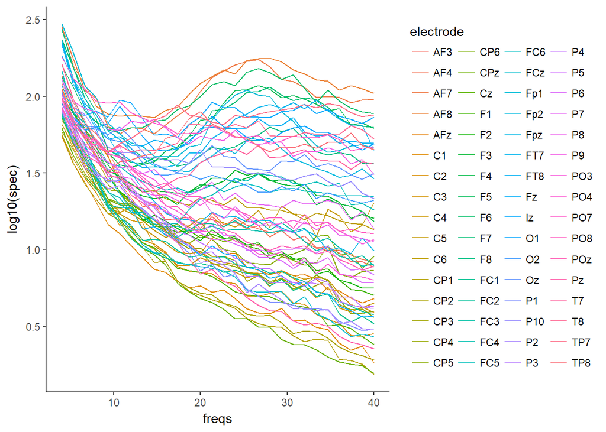

```r
spec_psd_two %>%
  mutate(freqs = freqs*128) %>%
  filter(freqs <= 40 & freqs >= 4) %>%
  group_by(freqs, electrode) %>%
  summarise(spec = mean(spec)) %>%
  ggplot(aes(x = freqs, y= log10(spec), colour = electrode)) +
  geom_line() +
  theme_classic()
```

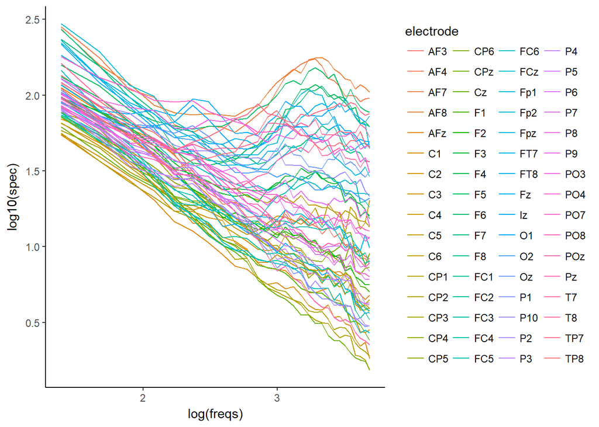

```r
spec_psd_two %>%
  mutate(freqs = freqs*128) %>%
  filter(freqs <= 40 & freqs >= 4) %>%
  group_by(freqs, electrode) %>%
  summarise(spec = mean(spec)) %>%
  ggplot(aes(x = log(freqs), y= log10(spec), colour = electrode)) +
  geom_line() +
  theme_classic()
```

Try facetting these plots on the touch and light variables. Hint: you also need to change *group_by()*.